# 社會科學統計方法

蔡佳泓

3/26/2021

# 1 課程目標

我們將介紹`R`的繪圖指令，包括`ggplot2`的套件中的指令，把資料視覺化。雖然之前我們已經看過很多例子，但是仍然有必要詳細介紹包括直方圖、折線圖、散佈圖等等圖形，結合`dplyr`套件中的指令，以培養視覺化資料的能力，並且在圖形上面顯示統計結果。例如我們可以視覺化資料的分佈並且找出每一個類別的平均數：

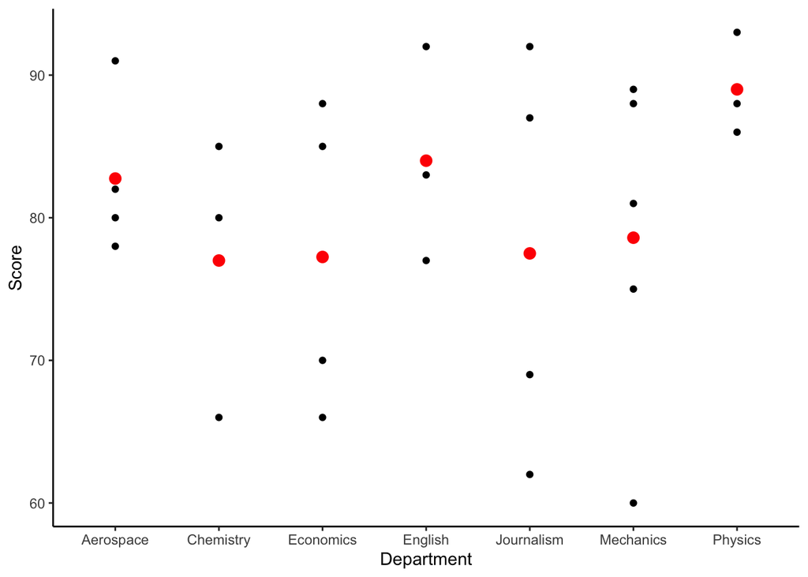

```r
file<-here("data","studentsfull.txt")
library(ggplot2)
students<-read.table(file, sep='', header=TRUE)
p <- ggplot(students, aes(x=Department, y=Score)) +
  geom_point() +
  theme_classic()

p + ggplot2::stat_summary(fun.y='mean', colour='red',size=3,
                    geom = "point")
```

# 2 基礎繪圖指令

有人說，「一張照片勝過千言萬語」。越來越來媒體報導、研究報告、論文以圖形表現變數之間的關係，讓讀者可以很快地了解。

`R`內建了許多基本的繪圖指令，讓我們可以很輕鬆地使用，但是`ggplot2`提升了繪圖的層次，所以我們必須學習並且熟練`ggplot2`。

## 2.1 基本元素

在`R`的基礎繪圖功能中，繪圖的元素有「點」、「線」、「大小」、「粗細」以及「顏色」等等。

- cex: 控制符號的大小
- col: 控制符號的顏色，也可以是灰階的濃度
- pch: 控制符號的形狀
- lwd: 控制線的粗細
- lty: 控制線的形狀

圖 2.1表示10種不同濃度黑色、10種不同形狀以及2種大小的點狀的散佈圖，加上粗細、顏色、形狀不同的垂直與水平線。

```r
xn<-c(1:10)
yn<-c(1:10)
col<-c(80, 75, 70, 60, 50, 40, 30, 20, 10, 0)
graycol<-paste("gray",col,sep="")
graycol
```

[1] “gray80” “gray75” “gray70” “gray60” “gray50” “gray40” “gray30” “gray20” [9] “gray10” “gray0”

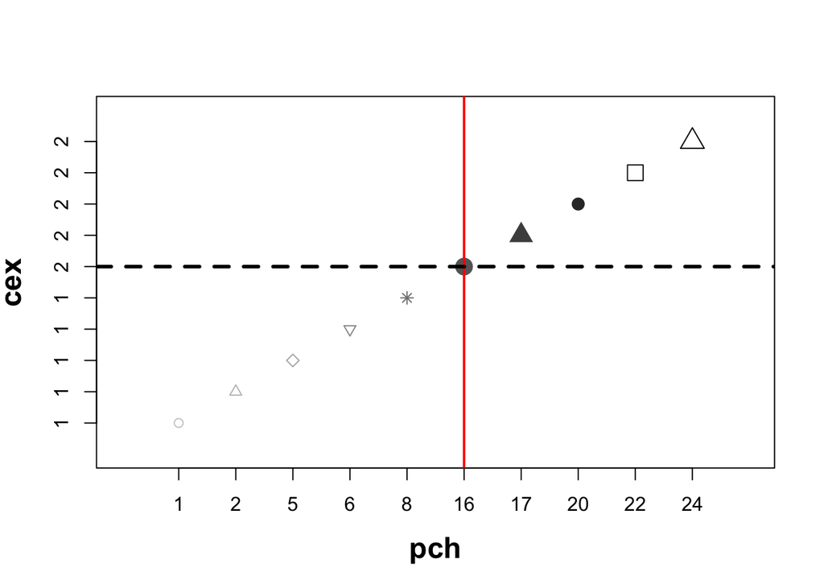

Figure 2.1: 圖型的元素

```r
plot(xn, yn,
  cex=c(rep(1, 5), rep(2,5)),
  col=graycol,
  pch=c(1,2,5,6,8, 16, 17, 20, 22, 24),
  xlab="pch", ylab="cex",
  xaxt="n", yaxt="n",
  xlim=c(0,11),ylim=c(0,11), font.lab=2, cex.lab=1.5)
axis(1, at=c(1:10), labels=c(1,2,5,6,8, 16, 17, 20, 22, 24))
axis(2, at=c(1:10), labels=c(rep(1, 5), rep(2,5)))
abline(v=6, lwd=2, col='red'); abline(h=6, lwd=3, lty=2)
```

從以上的指令以及圖形不難看出一些常用圖形參數。另外要說明幾個設定參數：

- xlab: X軸的標題
- ylab: Y軸的標題
- main: 圖形標題
- xlim: X軸最高的值
- ylim: Y軸最高的值
- xaxt=‘n’: 控制X軸不顯示任何數字
- yaxt=‘n’: 控制Y軸不顯示任何數字
- axis: X軸或是Y軸顯示的數字（labels ）以及位置（at ）
- font.lab: 控制X, Y軸名稱的大小
- cex.lab: 控制X, Y軸刻度名稱的大小

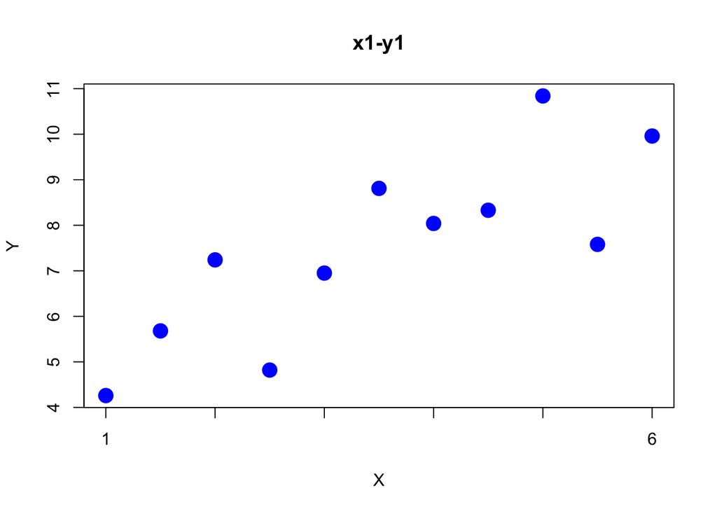

Figure 2.2: 散佈圖一

```r
with(anscombe, plot(x1, y1, pch=16, cex=2, col='blue',
     xlab='X', ylab='Y', main='x1-y1', xaxt='n'))
axis(side=1, labels=c(1,"" ,"" ,"" ,"" ,6), at=c(4,6,8,10,12,14))
```

在第一個步驟中，圖 2.2的X軸沒有刻度，在第二步驟，我們加上頭跟尾兩個刻度。換句話說，透過axis()函數，我們可以設定X或Y軸任意的刻度。

我們也可以先幫觀察值畫一個框，再用points這個函數，有同樣的效果，如圖2.3：

```r
with(anscombe, summary(x1))
```

```
##    Min. 1st Qu.  Median    Mean 3rd Qu.    Max.
##     4.0     6.5     9.0     9.0    11.5    14.0
```

```r
with(anscombe, summary(y1))
```

```
##    Min. 1st Qu.  Median    Mean 3rd Qu.    Max.
##    4.26    6.32    7.58    7.50    8.57   10.84
```

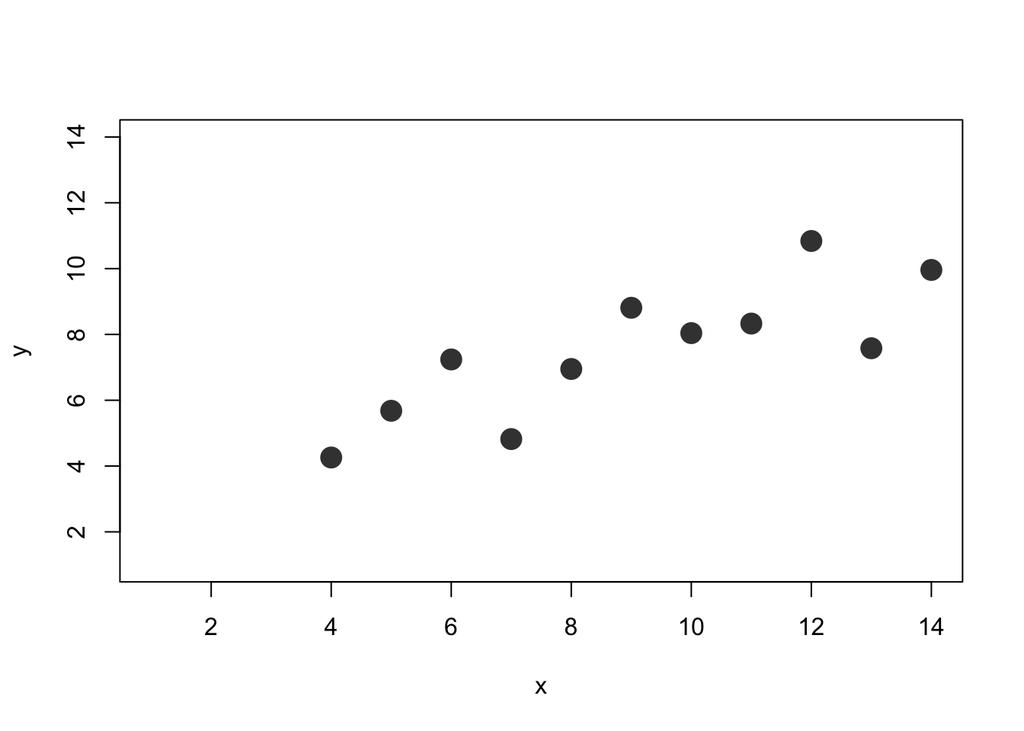

Figure 2.3: 散佈圖二

```r
x<-c(1: max(anscombe$x1))
y<-c(1: max(anscombe$x1))
plot(x, y, type='n')
with(anscombe, points(x1, y1, pch=16, cex=2, col='gray25'))
```

我們可以用points函式繪圖標示兩個變數對應的數值，並且用which()控制散佈圖。 圖2.4顯示的顏色或者形狀，類似加上第三個變數的效果：

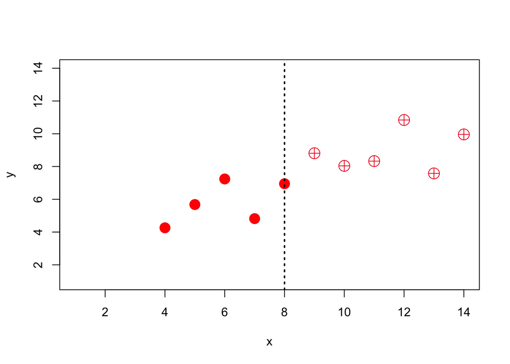

Figure 2.4: 散佈圖三

```r
x<-c(1: max(anscombe$x1))
y<-c(1: max(anscombe$x1))
plot(x, y, type='n')

with(anscombe, points(x1[which(x1<=8)],
        y1[which(x1<=8)], pch=16, cex=2, col='red'))
with(anscombe, points(x1[which(x1>8)],
      y1[which(x1>8)], pch=10, cex=2, col='#ee0022'))
abline(v=8, lwd=2, lty=3)
```

圖 2.4 顯示x1超過8是加上十字的圓點，小於8是紅色的點。

- 我們可以用colors()這個函式顯示657種顏色。
- 另外我們可以用#加上6碼的Hex指定`#RRGGBB`的顏色。可以查這個[網站](https://www.color-hex.com)輸入Hex6位數找到喜歡的顏色。
- 有時候我們想增加多一點資訊，可以用text在觀察點旁邊加上文字，讓讀者更容易瞭解觀察值的順位。pos 控制文字的位置。例如圖 2.5 顯示11個觀察值的落點。

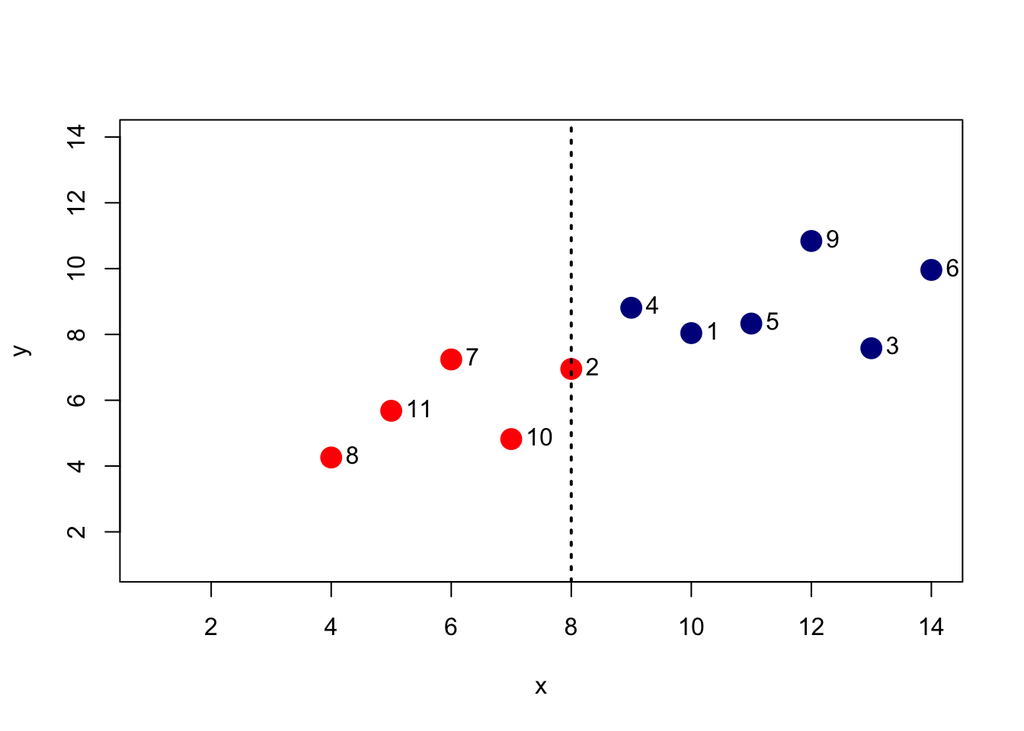

Figure 2.5: 散佈圖四

```r
plot(x, y, type='n')
with(anscombe, points(x1[which(x1<=8)],
        y1[which(x1<=8)], pch=16, cex=2, col='red'))
with(anscombe, points(x1[which(x1>8)],
        y1[which(x1>8)], pch=16, cex=2, col='darkblue'))
abline(v=8, lwd=2, lty=3)
with(anscombe, text(x1, y1,
            c(1: nrow(anscombe)), pos=4))
```

- 也可以貼上觀察值本身的數字如圖 2.6：

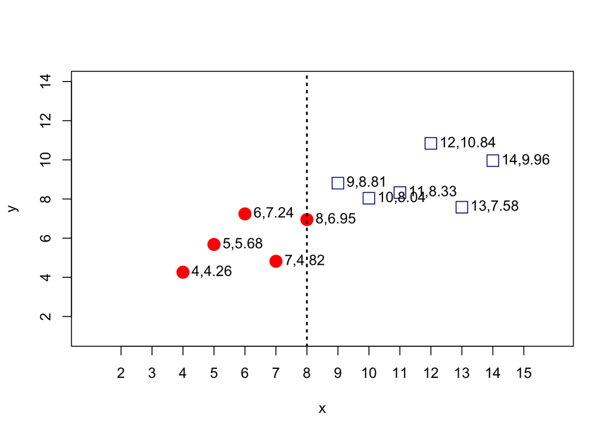

Figure 2.6: 散佈圖五

## 2.2 直方圖

直方圖可以表現單一類別變數的分佈，讓人一眼就可以看出哪一個類別有最多的次數或者百分比。例如圖 2.7 顯示學生的科系分佈：

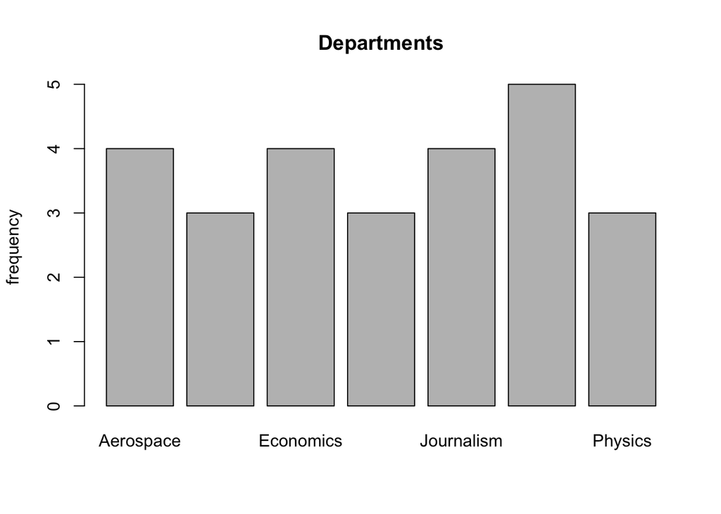

Figure 2.7: 直方圖一

```r
TXT<-here("data","studentsfull.txt")
students<-read.table(TXT, header=T, sep='')
stu <- table(students$Department)
barplot(stu, main="Departments",
xlab="", ylab="frequency")
```

直方圖的對象應該是具有名稱的摘要，所以要先把數字、字串或者是類別的向量改為表格的形式。直方圖也可以指定直方本身的顏色以及外框的顏色，例如圖 2.8 換了新的顏色。

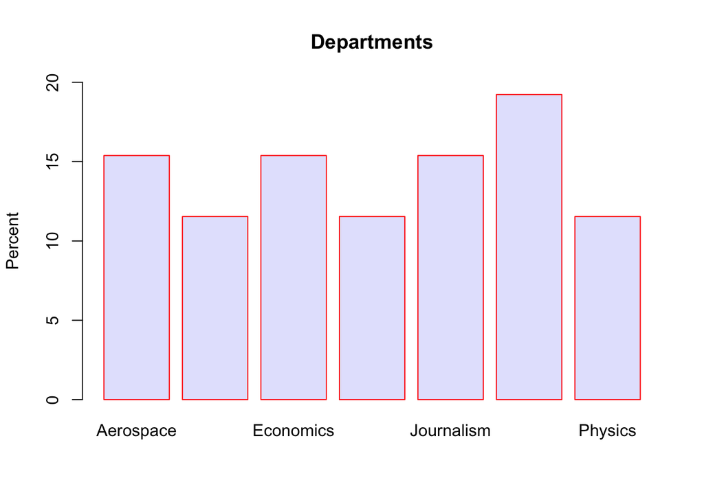

Figure 2.8: 直方圖二

```r
barplot(100*stu/nrow(students), main="Departments",
      xlab="", ylab="Percent", border='red',
      col='#0011EE22', ylim=c(0, 20))
```

如果圖例所使用的變數是類別變數，圖例函數寫成： legend = levels(students$Gender))，也就是回傳該變數的類別。如果在讀這筆資料時設定保留字串變數、不轉成類別變數。在此就要把性別轉為類別變數，才能帶出兩個類別，也就是legend = levels(as.factor(students$Gender))。

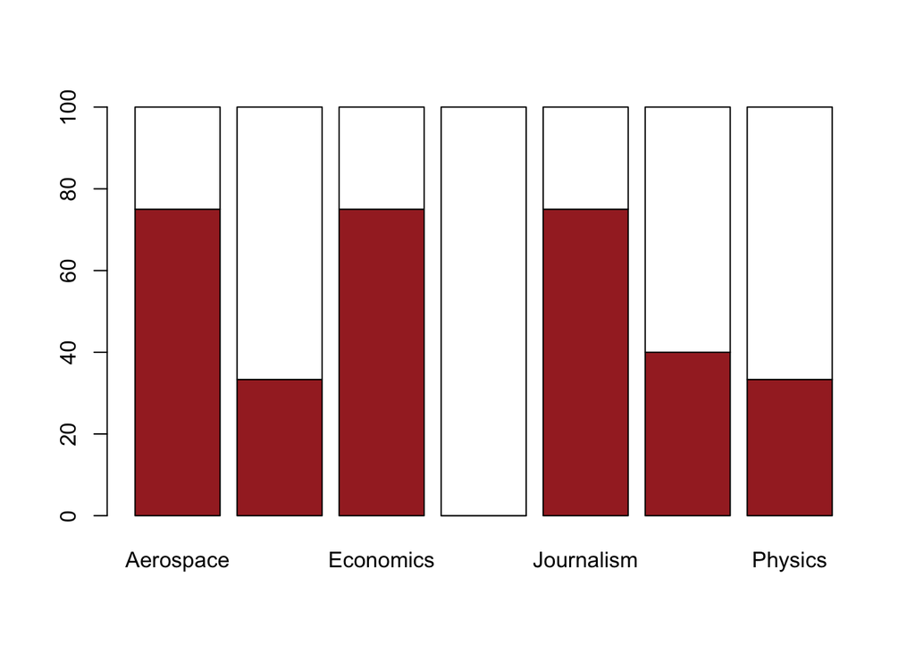

Figure 2.9: 直方圖三

```r
student.table <- table(students$Gender, students$Department)
barplot(100*prop.table(student.table, margin=2),
         col=c('brown', 'white'),
        legend = levels(students$Gender))
```

圖例的位置有“bottomright”, “bottom”, “bottomleft”, “left”, “topleft”, “top”, “topright”, “right”, “center”等等，比較常用的是topleft, topright, bottomright, bottomleft四種。

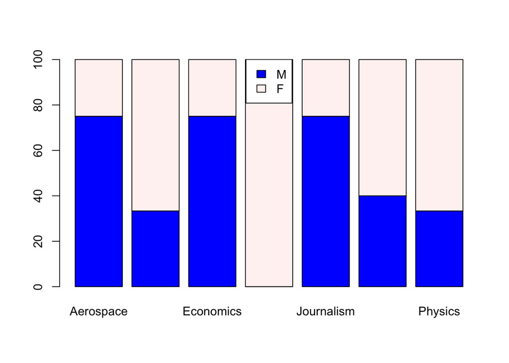

Figure 2.10: 直方圖與圖例

```r
student.table <- table(students$Gender, students$Department)
barplot(100*prop.table(student.table, margin=2),
         col=c('blue', '#EE330011'))
legend("top", fill=c('blue', '#EE330011'), c("M","F"))
```

如果想要更改類別的名稱，可以直接在barplot()之中設定參數，例如在直方圖 2.11，我們修改了類別的名稱：

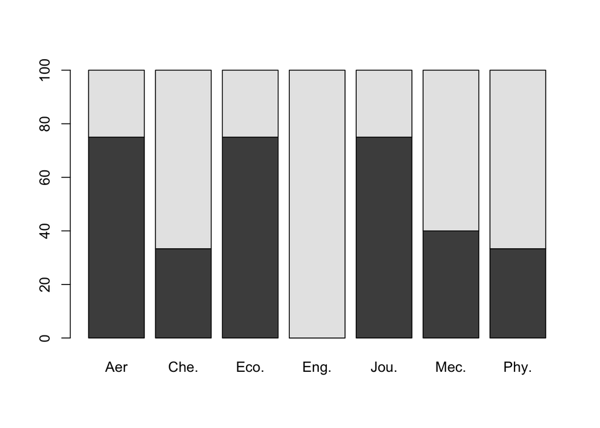

Figure 2.11: 直方圖四

```r
barplot(100*prop.table(student.table, margin=2),
      names.arg=c("Aer","Che.", "Eco.", "Eng.", "Jou.", "Mec.","Phy."))
```

## 2.3 盒型圖 (Box Plot)

盒型圖又稱為箱型圖，於1977年由普林斯頓大學統計系教授約翰·圖基（John Tukey）發明。可以表現單一連續變數的中位數、25分位數、75分位數、極端值等等，也可以比較不同類別之下，連續變數的分佈情形。

例如我們觀察mpg這個變數的盒型圖如圖 2.12：

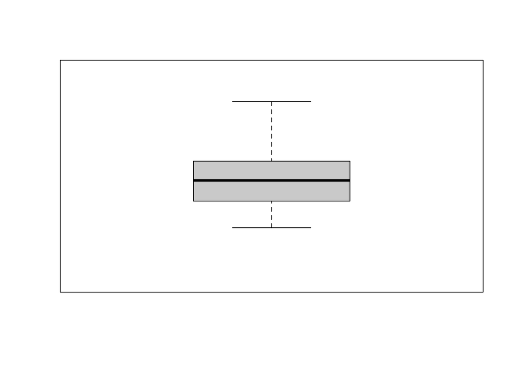

Figure 2.12: 箱型圖一

```r
boxplot(mtcars$mpg, ylim=c(0,40), yaxt='n')
```

中間的粗線代表中位數。盒型圖上方的線稱為inner fence或者是whisker，代表數列的極大值與75分位數加上四分位距的1.5倍兩個其中的極小值，下方的線代表數列的極小值與25分位數減去四分位距的1.5倍兩個其中的極大值。四分位距則是75分位數減去25分位數。超出inner fences被稱為極端值（outlier）。

為了確認以上的定義，計算這個變數的25與75分位數：

```r
quantile(mtcars$mpg, c(.25, .5, .75), type=6)
```

```
##   25%   50%   75%
## 15.27 19.20 22.80
```

```r
qu<-quantile(mtcars$mpg, c(.25, .5, .75), type=7)
qu
```

```
##   25%   50%   75%
## 15.43 19.20 22.80
```

```r
upper<- qu[3]+1.5*(qu[3]-qu[1])
lower<- qu[1]-1.5*(qu[3]-qu[1])
cat("upper", upper); cat("/", "lower", lower)
```

```
## upper 33.86
```

```
## / lower 4.363
```

```r
# upper inner fence
min(max(mtcars$mpg), upper)
```

```
## [1] 33.86
```

```r
# lower inner fence
max(min(mtcars$mpg), lower)
```

```
## [1] 10.4
```

畫盒型圖 2.13 對照上述的計算結果：

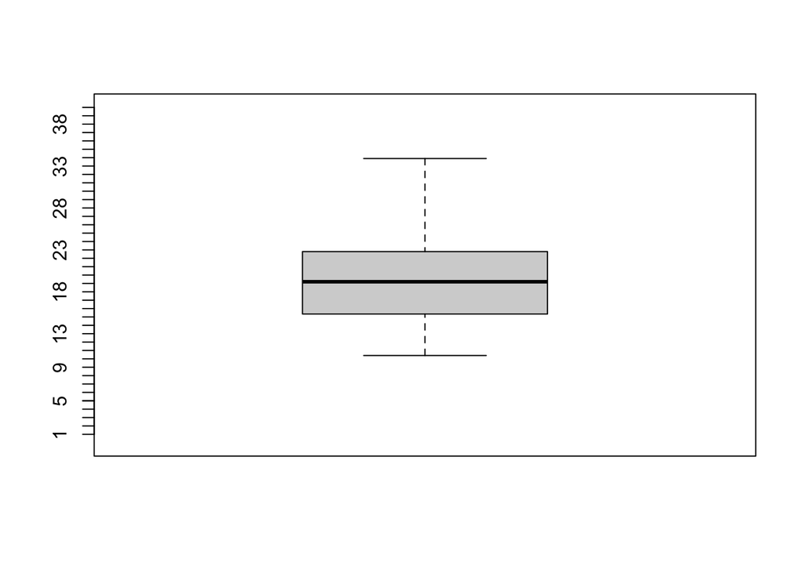

Figure 2.13: 盒型圖二

```r
boxplot(mtcars$mpg, ylim=c(0,40), yaxt='n')
axis(2, at=c(1:40, by=5), labels=c(1:40,by=5))
```

上述的資料並沒有極端值，我們可以觀察美國各州的面積，圖 2.14 顯示有些州的面積接近60萬平方英里，有的不到10萬平方英里：

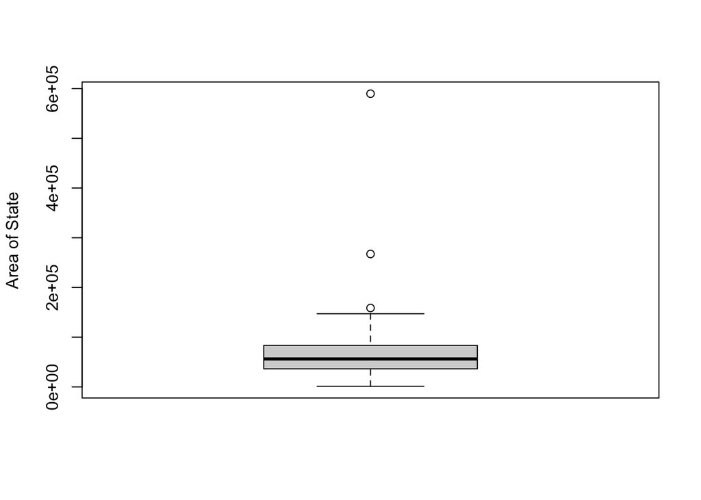

Figure 2.14: 盒型圖三

```r
boxplot(state.area, ylab="Area of State")
```

然後請輸入下列指令：

```
y<-state.abb

identify(rep(1, length(y)), y, labels=seq_along(y)))
```

然後用滑鼠對著圖形點擊，如果出現已經找到最近的點，可以按旁邊的finish，然後會呈現哪幾個觀察值被標示在圖形上面。例如第二個州是阿拉斯加，面積最大。

我們可以對類別變數繪製另一個連續變數的箱型圖，例如圖2.15：

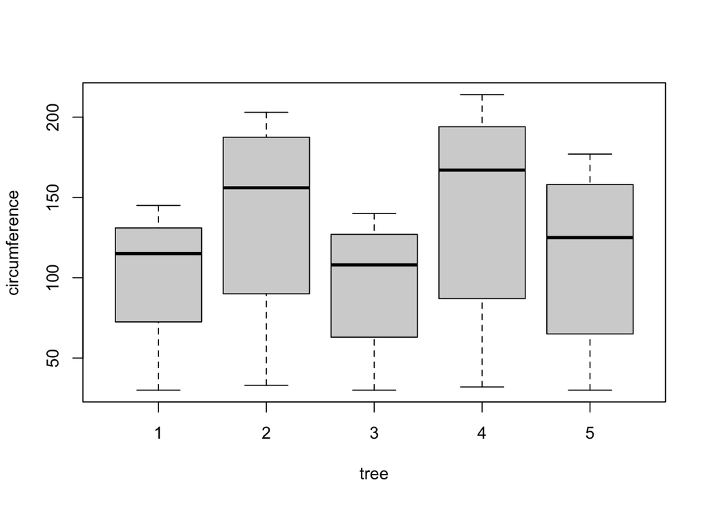

Figure 2.15: 盒型圖四

```r
Orange$tree <-ordered(Orange$Tree, levels=c(1,2,3,4,5))
with(Orange, boxplot(circumference ~ tree))
```

由上圖 2.15 可以看出，第一類型的四分位距比較小，其次是第三類型。而第四類型的中位數最大。

### 2.3.1 課間練習

☛請試著畫`ISLR`套件中資料的薪水盒型圖。薪水變數是該資料的列的名稱。

## 2.4 長條圖 (Histogram)

我們可以從長條圖觀察連續變數的分佈，例如偏態以及峰值等等。 因為連續變數有一定數量的值，而非像類別變數的值是離散的，所以應該用長條圖來呈現。例如圖 2.16 顯示美國50個州的傷害罪統計，有的州落在50件以內，有的州則在100到150中間：

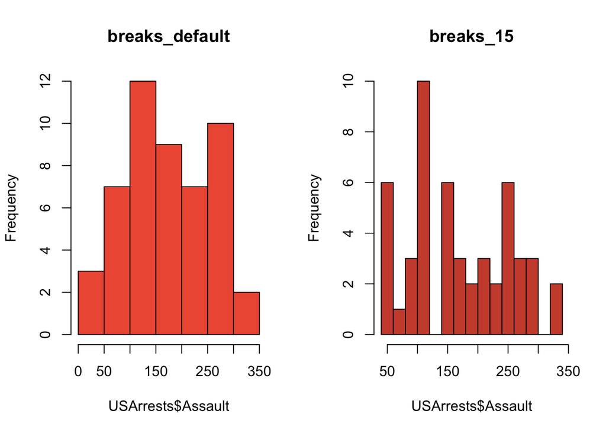

Figure 2.16: 長條圖一

```r
par(mfrow=c(1,2))
hist(USArrests$Assault, col="tomato2", main="breaks_default")
hist(USArrests$Assault, breaks = 15, col="tomato3",
     main="breaks_15")
```

上圖 2.16 的指令中，我們可以指定或者不指定長條的數目。不同的長條數目呈現不同的分佈。長條數目越多可能越接近資料，但是也會帶來許多雜訊。

連續變數的每一個值的相對比例可以幫助我們了解分佈型態，因此，freq=F參數強制長條圖呈現相對的比例，而非次數。圖 2.17 顯示傷害罪的機率密度。

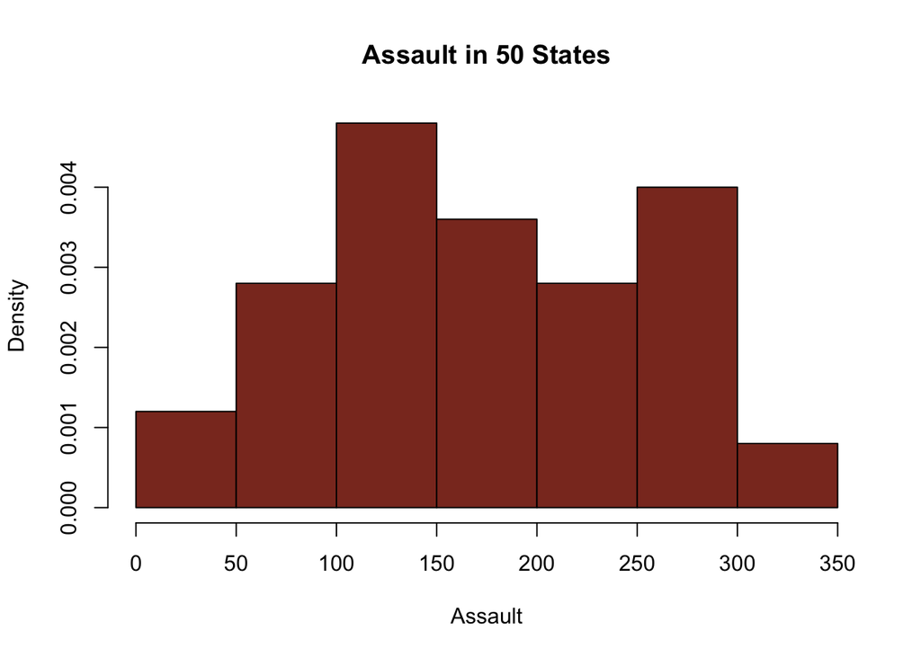

Figure 2.17: 長條圖二

```r
hist(USArrests$Assault, col="tomato4", freq = F,
     xlab="Assault", main="Assault in 50 States", breaks = 10)
```

`R`會自動挑選適合該變數分佈離散程度的寬度，breaks參數越大，寬度越小，有可能出現某一間隔沒有任何觀察值之狀況。但是寬度越大，變數的分佈越粗略。

我們用模擬的資料來表現長條圖的參數break的用途。我們從常態分佈的x抽出100個，計算平均值後記錄為y，然後重複1000次，也就是有1000個x的平均值。在圖 2.18，左邊的圖最多有10個等分，右邊的圖則是可以到50個，所以右邊的圖顯示比較多的直條。

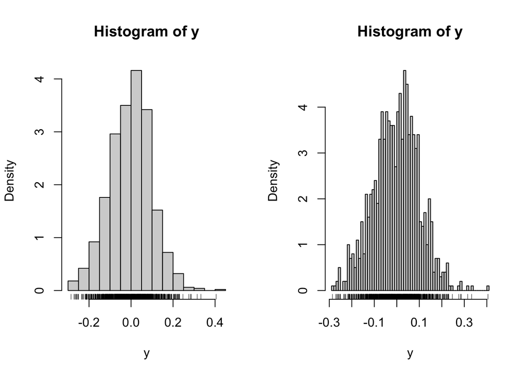

Figure 2.18: 兩個長條圖並列

```r
par(mfrow=c(1,2))

y <- c()
for (i in 1:1000)
{x=rnorm(1000,0,1)
 x.sample <- sample(x, 100)
  y[i]=mean(x.sample)}

hist(y, 10, probability = T)
rug(jitter(y))
hist(y, 50, probability = T)
rug(jitter(y))
```

在長條圖上面可以加上特定分布的曲線，例如常態分佈曲線或者是一致分佈曲線如圖 2.19：

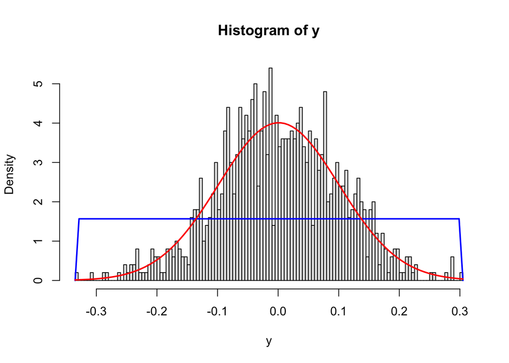

Figure 2.19: 加上機率密度曲線的長條圖

```r
par(mfrow=c(1,1))
set.seed(02138)
y <- c()
for (i in 1:1000)
{x=rnorm(1000,0,1)
 x.sample <- sample(x, 100)
  y[i]=mean(x.sample)}

hist(y, 100, probability = T, col="gray90")

curve(dunif(x, min=min(y), max=max(y)), add=T, col="blue", lwd=2)

curve(dnorm(x, mean=mean(y), sd=sd(y)), add=T, col="red", lwd=2)
```

從上面的圖可以看出模擬的資料近似常態分佈，而常態分佈曲線比一致分佈曲線更接近資料分佈。

我們再用中的price為例，用三種方法加上分布的曲線。由於這筆資料的單位比較大，所以先除以1000。第一種是直接加上機率密度曲線（粉紅）。第二種是加上右偏的卡方分佈曲線（藍）。第三種則是加上指數分佈曲線（黑）。指數分佈的函數為：

$$f(x|\lambda)=\lambda e^{-\lambda x}\quad x\ge 0$$

圖2.20顯示價格的機率密度：

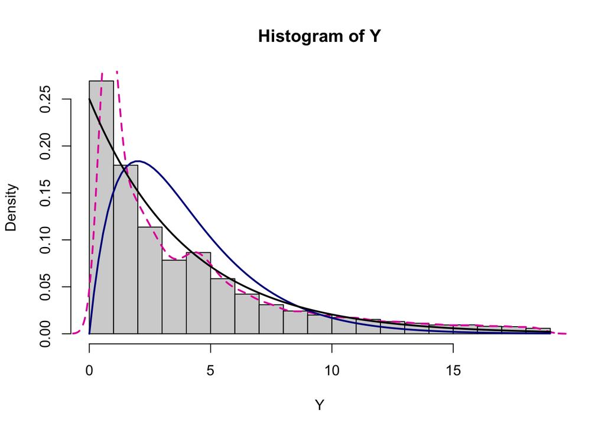

Figure 2.20: 鑽石價格機率密度

```r
Y<-ggplot2::diamonds$price/1000

hist(Y, freq =  F , breaks=25)
lines(density(Y), lty=2,
      lwd=2, col="#e122aa")


curve(dchisq(x, df=4), add=T,
      lwd=2, col="darkblue")

curve(dexp(x, rate=.25), lwd=2, add=T)
```

有關各種分布的語法可參考[Statistics Globe](https://statisticsglobe.com/probability-distributions-in-r)這個網站。

## 2.5 折線圖 (Line Chart)

之前在介紹散佈圖時，曾經設定參數type=‘n’，使觀察值不顯示出來，而除了type=‘n’，還有b, c, h, o, p等5個選項。而且，可以用單一變數繪圖表示分佈型態。

例如圖 2.21 顯示風速的趨勢：

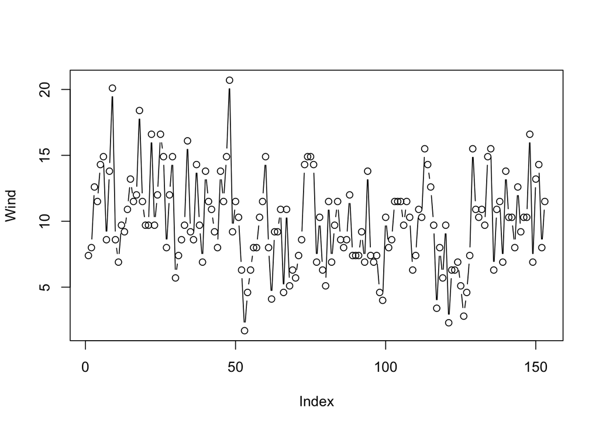

Figure 2.21: 空氣品質折線圖一

```r
with(airquality, plot(Wind, type='b'))
```

或者是圖 2.22 設定不同的顏色以及符號，顯示臭氧層的變化情形：

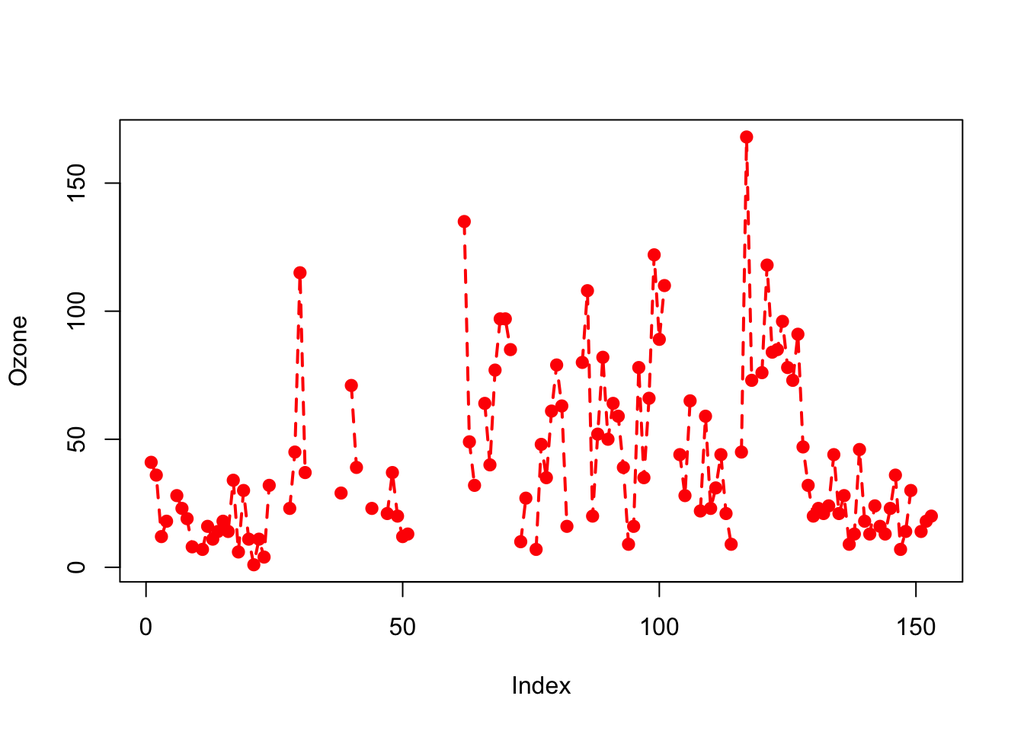

Figure 2.22: 空氣品質折線圖二

```r
with(airquality, plot(Ozone, type='o', pch=16,
                      cex=1.2, lty=2, lwd=2, col='red'))
```

### 2.5.1 時間序列資料

資料有時間序列的型態，適用以折線圖顯示，例如LakeHuron這筆資料是時間序列資料，裡面的參數設定為type=‘o’。圖2.23顯示湖水的折線圖：

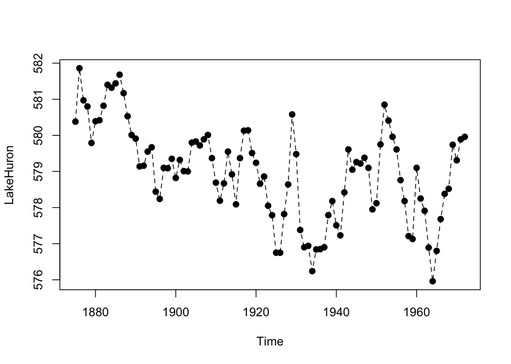

Figure 2.23: Lake Huron折線圖

```r
plot(LakeHuron, type = "o", pch=16, cex=1.2, lty=2)  ## Index plot
```

那麼我們要如何建立時間序列資料？ts()函式可以轉換一個資料框為時間序列資料，要注意設定起始的時間點，可以以月份來切分，如果頻率為1，就是以1年為單位，如果頻率為2，就是半年，頻率為4，就是3個月：

```r
CSV<-here("data","Tondutrend.csv")
trend<-read.csv(CSV, header=T, sep=",")
tonduts<-ts(trend, start=1992.6, frequency=2)
```

相對於其他軟體，`R`的優點在於允許時間點有缺漏，畫出來的圖形就有缺少某個或是某些時間點，不會強制連接前後兩個時間點。接下來是畫折線圖。圖 2.24 顯示2004年以來統獨趨勢一直相當穩定，但是在2016年之後偏統的支持度似乎上升，到了2019年又下降，而偏獨立的民意上升：

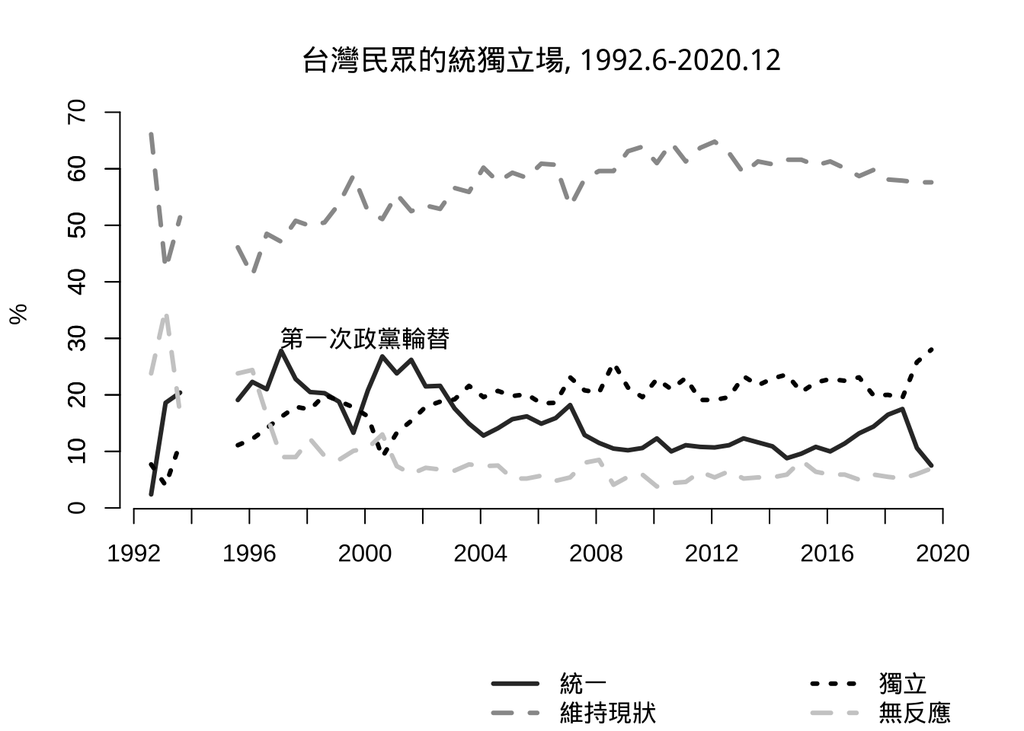

Figure 2.24: 統獨趨勢圖

```r
# Margin
par(xpd=NA, mar=par()$mar+c(2.5, 0, 0, 0),family='HanWangKaiMediumChuIn')
# Plot
plot(tonduts, plot.type=c("single"), lty=c(1,2,3,2),
     ylab="%",xlab=NULL,pch='1', lwd=3,frame.plot=F,
     col=c("gray20","gray60", "black", "gray80"),
     xaxt="n", main="台灣民眾的統獨立場, 1992.6-2020.12")
axis(1, at=seq(1992,2020,by=2))
axis(2, at=seq(10,70,by=10))
legend("bottomright", c("統一","維持現狀"),
        inset=c(0.35, -0.6), col=c("gray20","gray60"),
             lty=c(1,2), bty='n', lwd=3)
legend("bottomright", c("獨立","無反應"),
        inset=c(0, -0.6), col=c("black", "gray80"),
             lty=c(3,2), bty='n', lwd=3)
text(2000, 30, paste("第一次政黨輪替"))
```

在圖形 2.24中，我們設定xpd=NA，允許圖形超過界線，而且設定圖形的邊線可以到原來區域的底部2.5個文字。這是因為折線有四條，需要一定的空間容納圖例，而為了避免與圖形重疊起見，我們把圖例放在X軸右下方，所以除了要設定參數“bottomright”，還要設定inset(0.35, -0.6)以及inset(0, -0.6)。 除了設定圖例出現的位置，還可以設定bty=“n”，強制圖例沒有外框。

有時候`R`會出現figure margin too large的錯誤訊息，這時候請調整一下par(mar=c())，例如par(mar=c(-0.2,-0.2,0,0))

最後，我們加上一點註解文字到圖形上面，當然，我們可以加上線條或是箭頭，請大家研究一下segment這個指令。相信這個折線圖會讓你的報告比其他軟體畫的圖看起來更專業。

這張圖裡面有中文，所以練習時，我們需要設定中文字型，不然會顯示亂碼。如果你打開字體簿，可以找PostScript名稱，然後在par()裡面設定參數family=""，就像底下的語法。

```
library(here);library(foriegn)
CSV<-here("data","Tondutrend.csv")
trend<-read.csv(CSV, header=T, sep=",")
tonduts<-ts(trend, start=1992.6, frequency=2)
par(xpd=NA, mar=par()$mar+c(2.5, 0, 0, 0),
    family='HanWangKaiMediumChuIn')
```

另一個做法是找字體的檔案，設定字體，就像底下的語法。

```
library(here);library(foriegn);library(showtext)
showtext.auto()
font.add("細明體", "MingLiu.ttf")
par(xpd=NA,
    mar=par()$mar+c(0, 0, 0, 0),
    family='細明體')
```

### 2.5.2 課間練習

☛請畫圖表示MASS::accdeaths的趨勢。

## 2.6 特殊點狀圖

symbols()可以產生指定形狀、大小的散佈圖，而且可以進一步根據另一個變數的觀察值，調整散佈點的大小，例如圖 顯示兩個變數的散佈圖，加上另一個連續變數的大小程度，見圖2.25：

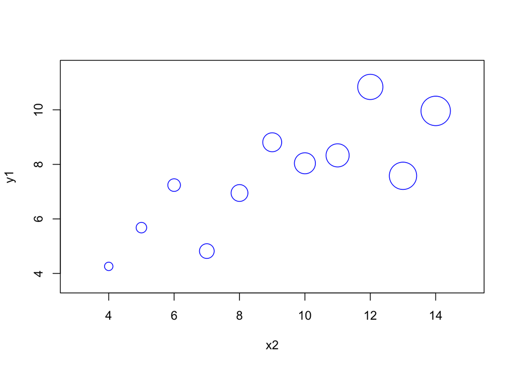

Figure 2.25: 特殊點狀圖一

```r
with(anscombe, symbols(x2, y1, circles=anscombe$x1,
          inches=0.2, fg='blue'))
```

可以看出有些圈圈比較大，有些比較小。再舉一個例子，見圖2.26：

：

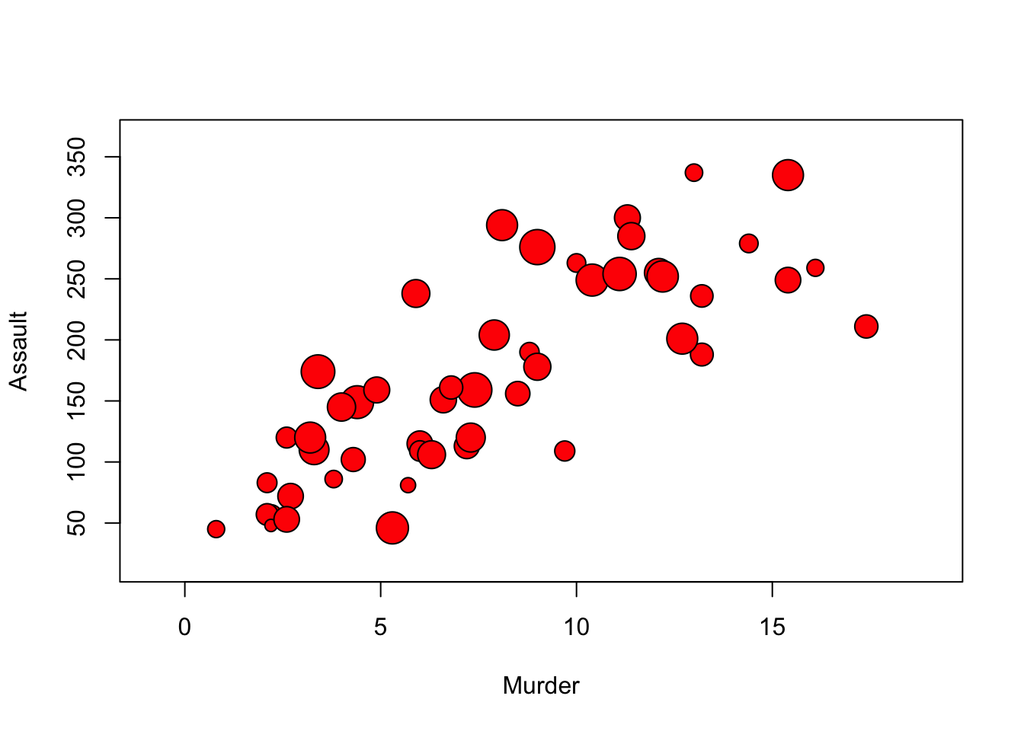

Figure 2.26: 特殊點狀圖二

```r
with(USArrests, symbols(Murder, Assault, circles=UrbanPop,
                         inches=0.12, bg="red"))
```

### 2.6.1 課間練習

☛請畫圖表示MASS::Boston這筆資料中，與生師比(ptratio)與房價中位數(medv)的關係，並且考慮低社會地位人口比例(lstat)的作用。

# 3 作業

1. 請針對mtcars這筆資料的wt以及mpg繪製散佈圖，並且加上車輛的名稱。

2. 請針對ChickWeight的，Diet變數畫出直方圖，並且標示次數（提示：text(x, y, labels)，x, y 分別是標示次數的位置，而標示次數要轉為字串）。

3. 請畫直方圖表示mtcars這筆資料中的變速箱（am）是屬於自動或是手動排檔之中，gear的比例。

4. 請嘗試讀取PP0797B2.sav這筆資料，然後畫長條圖表示partyid這個變數中，不同年齡(age)是否同意Q9（政府所做的是大多數是正確的）的相對次數。請注意讀取SPSS資料的方式，有的方式可以不讀取原先資料設定的遺漏值。

5. 請畫圖表示Nile的水位變化，並且指出大概是哪一年的水位最低與最高：

6. 請從CS3171D1A.csv資料選取前五個縣市，然後針對老年人口比率畫2000至2010年的折線圖，並且於圖例標示五個縣市。

7. 請畫箱型圖表示mtcars這筆資料中的gear的各個類別的hp分佈。

8. 請畫圖表示美國1986年調查的嬰兒體重(`MASS::birthwt`)的分佈。

9. 請用折線圖表示Orange資料裡五種樹的樹齡與樹圍之間的關係。（提示：請考慮用for迴圈。另外請用subset()指定每一種樹的資料。）

10. 請觀察`reshape2::tips`這筆資料的tips與total_bill兩個變數的關係，並且標記顧客是否抽煙(smoker)。請記得加上圖例。

# 4 更新日期

最後更新日期 02/06/2021